# 화성시 최적 버스노선 방안

### **경기대학교**

(팀 대표)

윤대훈

(팀원)

김동현

유양선

윤도원

최종욱

# 시각화

1. 화성시 **인구밀도** 시각화
2. 화성시 **유동인구** 시각화
3. 화성시 **버스노선** 분석 시각화

## 1. 화성시 인구밀도 시각화

```python
# 필요 패키지 설치
import geopandas as gpd
import matplotlib as mpl
import matplotlib.pyplot as plt

import deckgljupyter.Layer as deckgl
from geoband.API import *

import warnings
warnings.filterwarnings('ignore')
```

```python
# 인구밀도 데이터 로드
df_pop = gpd.read_file('./data/PJT001_h_100m_cell_pop.geojson')
```

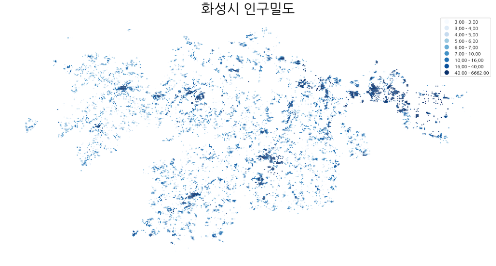

```python
# 시각화 사이즈 지정
plt.rcParams['figure.figsize'] = (20, 10)

# 한국어 제목을 사용하기 위한 폰트설정
# 폰트 설정
mpl.rc('font', family='NanumGothic')
# 유니코드에서 음수 부호설정
mpl.rc('axes', unicode_minus=False)

# 변수 설정 가능 -> 인구별 분포 또한 파악 가능
variable = 'pop_ttl' # 먼저 전체 인구밀도로 한정

ax = df_pop.plot(column = variable, legend = True, scheme = 'Quantiles', cmap = 'Blues', k = 9)
#########################################################################
# scheme
#    Equal_interval : 동일한 간격으로 구분
#   Quantiles : 사분위 수를 구하여 구분
#   Fisher_Jenks : 클래스내 분산을 줄이고 클래스 끼리의 분산을 최대화하는 방식

# k
#   범주 구분 개수
#########################################################################

ax.set_axis_off()
ax.set_title('화성시 인구밀도', fontsize = 30)
plt.show()
```

## 2. 화성시 유동인구 시각화

```python
# 작업환경에 있는 데이터 로드
GetCompasData('PJT001_h_100m_cell_flow.geojson')
```

```python
# df_flow에 할당
df_flow = gpd.read_file('PJT001_h_100m_cell_flow.geojson')

# 데이터 타입을 정수 형태로 변환
df_flow['ymd'] = df_flow['ymd'].astype('int')
```

```python
# 20160703 일자 데이터 추출
df_flow = df_flow[df_flow['ymd']==20180703]
df_flow.reset_index(drop=True, inplace=True)
df_flow.fillna(0, inplace=True)

# 시각화할 시간대를 한정
# 출근시간과 퇴근시간, 점시시간의 유동인구 파악
#출근시간
target_time = 't08_09'
df_target = df_flow[target_time]
#점심시간
target_time = 't12_13'
df_target = df_flow[target_time]
#퇴근시간
target_time = 't18_19'
df_target = df_flow[target_time]
```

```python
# 10 이하의 데이터는 제거
for i in range(len(df_target)) :
    if df_target[[i][0]] < 10 :
        df_target = df_target.drop(i)
```

```python
mon_go_df = df_flow.iloc[df_target.keys(),]

max_value = df_target.max()
default = 70
```

```python
# 시각화 함수에 넣어줄 형태로 데이터를 만듭니다.
data = []
for idx, row in mon_go_df[['geometry', target_time]].iterrows():
    lonlat = [[lon, lat] for lon, lat in zip(*df_flow['geometry'].iloc[idx].exterior.coords.xy)]
    data.append({
        'polygon': lonlat,
        'value': row[target_time],
        'color': [255, 0, 0, default + 255 * row[target_time] / max_value]
    })
```

```python
access_token = 'pk.eyJ1IjoiZGFlZG9sIiwiYSI6ImNqZGpqbmpnYzFscm8yd245YXM5MWQxeGgifQ.ACxKlSjUthNpixmVX2faMw'
view_options = {
    'center': [126.908, 37.132],
    'zoom': 12,
    'bearing': 0,
    'pitch': 60,
    'style': 'mapbox://styles/mapbox/dark-v9',
    'access_token': access_token
}

m = deckgl.Map(**view_options)
m.add(deckgl.PolygonLayer(data,
                          getElevation=1,
                          getFillColor='d => d.color',
                          tooltip=["value"],
                          pickable=True))
m.show()
```

[interactive chart not shown]

## 3. 화성시 버스노선 분석 시각화

Power BI를 활용하여 시각화  
보고서 5장

버스노선이 화성시 내부의 정류장을 하나라도 경유할 경우 화성시 버스노선으로 간주했다.  
(데이터 전처리 파일 참고)

### 1. 화성시 버스노선 시각화

- 활용데이터
  - PJT001_stations_table.csv
  - PJT001_routestationinfo.csv
- 이상치 정보
  - 버스노선번호 : 5-2 , 버스노선고유ID : 241205007
  - 버스노선번호 : H6005, 버스노선고유ID : 233000275
- 특정 버스노선번호만을 선택해 시각화 가능
- 해당 노선이 경유하는 정류소 중 특정 순서정류소 확인가능
- 공항, 광역, 마을, 시내를 구분하여 시각화 가능
- 중복되는 버스노선 버스가 있어 버스노선고유 ID구분

### 2. 화성시 정류소 시각화

- 활용데이터
  - PJT001_TripChain.csv
  - PJT001_stations_table 수집건수 제한을 두지 않고 최초승차지와 최종하차지 기준으로 시각화
- Text Filter를 통해 검색하여 정보 확인 가능
- 2018년 7월 3일 데이터 활용
- 정류장별 경유노선수
- 승차정류소에 따른 하차정류소
- 하차정류소에 따른 승차정류소

### 3. 노선번호별 승차 및 하차 시각화

- 활용데이터
  - PJT001_TripChain.csv
  - PJT001_stations_table
  - PJT001_routestationmapping 수집건수 = 1 인 데이터로 전처리, 특정노선 탑승시 승차 및 하차 정류소 시각화
- 승차정류소, 하차정류소의 관할관청별 필터링
- 노선번호병 필터링
- 노선번호를 Text Filter를 통해 확인가능

### 4. 행정구역별 OD 시각화

- 활용데이터
  - PJT001_sk_emd_od.csv
- 노선 생성시 고려해야 할 기준인 읍면동 간 유동인구를 시각적으로 파악하기 위해 진행했다.
- 시간대, 연 월 일, 출발, 도착을 지정 할 수 있다.

### 5. 노선제안 시각화

- 활용데이터
  - 노선제안.xlsx
- 기존 정류장을 활용하여 좌표를 선택한 후 시각화를 진행했음
- 노선명 선택 가능
- 경유정류소 순서별 선택 가능
- 애니매이션을 통해 동적 시각화 가능
- 최근 대두된 새솔동 신노선 신설요구를 충족하기위해 16, 17번 노선은 새솔동 기준

```python
from IPython.display import IFrame

powerBiEmbed = 'https://app.powerbi.com/view?r=eyJrIjoiNDRiNjlkYTktYjBjOS00YmEwLWJhYWMtMTRkZTFhMTJhNWI1IiwidCI6ImYwOWE0ZWYzLTk3OGQtNDM0ZS04OWRhLWEyOWI5ZjlmM2MzMiIsImMiOjEwfQ%3D%3D'
IFrame(powerBiEmbed, width=933, height=700)
```

[interactive chart not shown]